# BIS 15L Midterm 2

## Instructions

Answer the following questions and complete the exercises in RMarkdown. Please embed all of your code and push your final work to your repository. Your code should be organized, clean, and run free from errors. Be sure to **add your name** to the author header above. You may use any resources to answer these questions (including each other), but you may not post questions to Open Stacks or external help sites. There are 10 total questions.

Make sure to use the formatting conventions of RMarkdown to make your report neat and clean! Your plots should use consistent aesthetics throughout.

This exam is due by **12:00p on Tuesday, February 22**.

```r
options(scipen=999)
```

## Gapminder

For this assignment, we are going to use data from [gapminder](https://www.gapminder.org/). Gapminder includes information about economics, population, social issues, and life expectancy from countries all over the world. We will use three data sets, so please load all three as separate objects.

```r
library(gapminder)
```

1. population_total.csv
2. income_per_person_gdppercapita_ppp_inflation_adjusted.csv
3. life_expectancy_years.csv

```r
library(tidyverse)
library(naniar)
library(janitor)
library(here)
library(RColorBrewer)
library(paletteer)
```

```r
pop_total <- readr::read_csv("data/population_total.csv")
income_ppp_gpd <-readr::read_csv("data/income_per_person_gdppercapita_ppp_inflation_adjusted.csv")
life_expectancy <- readr::read_csv("data/life_expectancy_years.csv")
```

1. (3 points) Once you have an idea of the structure of the data, please make each data set tidy (hint: think back to pivots) and store them as new objects. You will need both the original (wide) and tidy (long) data!

```r
naniar::miss_var_summary(pop_total)
```

```
## # A tibble: 302 x 3
##    variable n_miss pct_miss
##    <chr>     <int>    <dbl>
##  1 country       0        0
##  2 1800          0        0
##  3 1801          0        0
##  4 1802          0        0
##  5 1803          0        0
##  6 1804          0        0
##  7 1805          0        0
##  8 1806          0        0
##  9 1807          0        0
## 10 1808          0        0
## # ... with 292 more rows
```

```r
summary(pop_total)
```

[output not shown]

[output cut: 652 more lines]

```
##  Max.   :1490000000   Max.   :1480000000   Max.   :1480000000
##       2097                 2098                 2099
##  Min.   :       796   Min.   :       796   Min.   :       795
##  1st Qu.:   2075000   1st Qu.:   2060000   1st Qu.:   2040000
##  Median :  11000000   Median :  11000000   Median :  11000000
##  Mean   :  55559477   Mean   :  55586126   Mean   :  55557763
##  3rd Qu.:  46550000   3rd Qu.:  46550000   3rd Qu.:  46550000
##  Max.   :1470000000   Max.   :1460000000   Max.   :1450000000
##       2100
##  Min.   :       797
##  1st Qu.:   2025000
##  Median :  11000000
##  Mean   :  55594536
##  3rd Qu.:  46600000
##  Max.   :1450000000
```

```r
glimpse(pop_total)
```

```
## Rows: 195
## Columns: 302
## $ country <chr> "Afghanistan", "Albania", "Algeria", "Andorra", "Angola", "Ant~
## $ `1800`  <dbl> 3280000, 400000, 2500000, 2650, 1570000, 37000, 534000, 413000~
## $ `1801`  <dbl> 3280000, 402000, 2510000, 2650, 1570000, 37000, 520000, 413000~
## $ `1802`  <dbl> 3280000, 404000, 2520000, 2650, 1570000, 37000, 506000, 413000~
## $ `1803`  <dbl> 3280000, 405000, 2530000, 2650, 1570000, 37000, 492000, 413000~
## $ `1804`  <dbl> 3280000, 407000, 2540000, 2650, 1570000, 37000, 479000, 413000~
## $ `1805`  <dbl> 3280000, 409000, 2550000, 2650, 1570000, 37000, 466000, 413000~
## $ `1806`  <dbl> 3280000, 411000, 2560000, 2650, 1570000, 37000, 453000, 413000~
## $ `1807`  <dbl> 3280000, 413000, 2560000, 2650, 1570000, 37000, 441000, 413000~
## $ `1808`  <dbl> 3280000, 414000, 2570000, 2650, 1570000, 37000, 429000, 413000~
## $ `1809`  <dbl> 3280000, 416000, 2580000, 2650, 1570000, 37000, 417000, 413000~
## $ `1810`  <dbl> 3280000, 418000, 2590000, 2650, 1570000, 37000, 420000, 413000~
## $ `1811`  <dbl> 3280000, 420000, 2600000, 2650, 1570000, 37000, 422000, 413000~
```

[output cut: 289 more lines]

```r
pop_total
```

```
## # A tibble: 195 x 302
##    country `1800` `1801` `1802` `1803` `1804` `1805` `1806` `1807` `1808` `1809`
##    <chr>    <dbl>  <dbl>  <dbl>  <dbl>  <dbl>  <dbl>  <dbl>  <dbl>  <dbl>  <dbl>
##  1 Afghan~ 3.28e6 3.28e6 3.28e6 3.28e6 3.28e6 3.28e6 3.28e6 3.28e6 3.28e6 3.28e6
##  2 Albania 4   e5 4.02e5 4.04e5 4.05e5 4.07e5 4.09e5 4.11e5 4.13e5 4.14e5 4.16e5
##  3 Algeria 2.5 e6 2.51e6 2.52e6 2.53e6 2.54e6 2.55e6 2.56e6 2.56e6 2.57e6 2.58e6
##  4 Andorra 2.65e3 2.65e3 2.65e3 2.65e3 2.65e3 2.65e3 2.65e3 2.65e3 2.65e3 2.65e3
##  5 Angola  1.57e6 1.57e6 1.57e6 1.57e6 1.57e6 1.57e6 1.57e6 1.57e6 1.57e6 1.57e6
##  6 Antigu~ 3.7 e4 3.7 e4 3.7 e4 3.7 e4 3.7 e4 3.7 e4 3.7 e4 3.7 e4 3.7 e4 3.7 e4
##  7 Argent~ 5.34e5 5.2 e5 5.06e5 4.92e5 4.79e5 4.66e5 4.53e5 4.41e5 4.29e5 4.17e5
##  8 Armenia 4.13e5 4.13e5 4.13e5 4.13e5 4.13e5 4.13e5 4.13e5 4.13e5 4.13e5 4.13e5
##  9 Austra~ 2   e5 2.05e5 2.11e5 2.16e5 2.22e5 2.27e5 2.33e5 2.39e5 2.46e5 2.52e5
## 10 Austria 3   e6 3.02e6 3.04e6 3.05e6 3.07e6 3.09e6 3.11e6 3.12e6 3.14e6 3.16e6
## # ... with 185 more rows, and 291 more variables: 1810 <dbl>, 1811 <dbl>,
## #   1812 <dbl>, 1813 <dbl>, 1814 <dbl>, 1815 <dbl>, 1816 <dbl>, 1817 <dbl>,
## #   1818 <dbl>, 1819 <dbl>, 1820 <dbl>, 1821 <dbl>, 1822 <dbl>, 1823 <dbl>,
## #   1824 <dbl>, 1825 <dbl>, 1826 <dbl>, 1827 <dbl>, 1828 <dbl>, 1829 <dbl>,
## #   1830 <dbl>, 1831 <dbl>, 1832 <dbl>, 1833 <dbl>, 1834 <dbl>, 1835 <dbl>,
## #   1836 <dbl>, 1837 <dbl>, 1838 <dbl>, 1839 <dbl>, 1840 <dbl>, 1841 <dbl>,
## #   1842 <dbl>, 1843 <dbl>, 1844 <dbl>, 1845 <dbl>, 1846 <dbl>, 1847 <dbl>, ...
```

```r
long_pop_total <-
  pop_total%>%
  pivot_longer("1800":"2100",names_to = "years", values_to = "total_ population")
long_pop_total
```

```
## # A tibble: 58,695 x 3
##    country     years `total_ population`
##    <chr>       <chr>               <dbl>
##  1 Afghanistan 1800              3280000
##  2 Afghanistan 1801              3280000
##  3 Afghanistan 1802              3280000
##  4 Afghanistan 1803              3280000
##  5 Afghanistan 1804              3280000
##  6 Afghanistan 1805              3280000
##  7 Afghanistan 1806              3280000
##  8 Afghanistan 1807              3280000
##  9 Afghanistan 1808              3280000
## 10 Afghanistan 1809              3280000
## # ... with 58,685 more rows
```

```r
wide_pop_total<-pop_total
```

```r
glimpse(income_ppp_gpd)
```

```
## Rows: 193
## Columns: 242
## $ country <chr> "Afghanistan", "Albania", "Algeria", "Andorra", "Angola", "Ant~
## $ `1800`  <dbl> 603, 667, 715, 1200, 618, 757, 1640, 514, 817, 1850, 775, 1450~
## $ `1801`  <dbl> 603, 667, 716, 1200, 620, 757, 1640, 514, 822, 1850, 775, 1450~
## $ `1802`  <dbl> 603, 667, 717, 1200, 623, 757, 1650, 514, 826, 1860, 775, 1450~
## $ `1803`  <dbl> 603, 667, 718, 1200, 626, 757, 1650, 514, 831, 1870, 775, 1450~
## $ `1804`  <dbl> 603, 667, 719, 1210, 628, 757, 1660, 514, 836, 1880, 775, 1450~
## $ `1805`  <dbl> 603, 668, 720, 1210, 631, 757, 1660, 514, 841, 1880, 776, 1450~
## $ `1806`  <dbl> 603, 668, 721, 1210, 634, 757, 1670, 514, 845, 1890, 776, 1450~
## $ `1807`  <dbl> 603, 668, 722, 1210, 637, 758, 1680, 514, 850, 1900, 776, 1450~
## $ `1808`  <dbl> 603, 668, 723, 1220, 640, 758, 1680, 514, 855, 1910, 776, 1450~
## $ `1809`  <dbl> 603, 668, 724, 1220, 642, 758, 1690, 514, 860, 1920, 776, 1450~
## $ `1810`  <dbl> 604, 668, 725, 1220, 645, 758, 1690, 514, 865, 1920, 777, 1450~
## $ `1811`  <dbl> 604, 668, 726, 1220, 648, 758, 1700, 515, 869, 1940, 777, 1450~
```

[output cut: 229 more lines]

```r
summary(income_ppp_gpd)
```

[output not shown]

[output cut: 344 more lines]

```
##  Max.   :143000   Max.   :146000   Max.   :149000   Max.   :153000
##       2033             2034             2035             2036
##  Min.   :   577   Min.   :   588   Min.   :   600   Min.   :   612
##  1st Qu.:  5380   1st Qu.:  5490   1st Qu.:  5600   1st Qu.:  5710
##  Median : 16000   Median : 16400   Median : 16700   Median : 17000
##  Mean   : 24083   Mean   : 24577   Mean   : 25078   Mean   : 25576
##  3rd Qu.: 35500   3rd Qu.: 36200   3rd Qu.: 37000   3rd Qu.: 37700
##  Max.   :156000   Max.   :159000   Max.   :162000   Max.   :165000
##       2037             2038             2039             2040
##  Min.   :   625   Min.   :   637   Min.   :   650   Min.   :   664
##  1st Qu.:  5830   1st Qu.:  5950   1st Qu.:  6070   1st Qu.:  6190
##  Median : 17400   Median : 17700   Median : 18100   Median : 18500
##  Mean   : 26108   Mean   : 26636   Mean   : 27181   Mean   : 27731
##  3rd Qu.: 38500   3rd Qu.: 39300   3rd Qu.: 40100   3rd Qu.: 40900
##  Max.   :169000   Max.   :172000   Max.   :176000   Max.   :179000
```

```r
naniar::miss_var_summary(income_ppp_gpd)
```

```
## # A tibble: 242 x 3
##    variable n_miss pct_miss
##    <chr>     <int>    <dbl>
##  1 country       0        0
##  2 1800          0        0
##  3 1801          0        0
##  4 1802          0        0
##  5 1803          0        0
##  6 1804          0        0
##  7 1805          0        0
##  8 1806          0        0
##  9 1807          0        0
## 10 1808          0        0
## # ... with 232 more rows
```

```r
wide_income_ppp_gpd<- income_ppp_gpd
wide_income_ppp_gpd
```

```
## # A tibble: 193 x 242
##    country `1800` `1801` `1802` `1803` `1804` `1805` `1806` `1807` `1808` `1809`
##    <chr>    <dbl>  <dbl>  <dbl>  <dbl>  <dbl>  <dbl>  <dbl>  <dbl>  <dbl>  <dbl>
##  1 Afghan~    603    603    603    603    603    603    603    603    603    603
##  2 Albania    667    667    667    667    667    668    668    668    668    668
##  3 Algeria    715    716    717    718    719    720    721    722    723    724
##  4 Andorra   1200   1200   1200   1200   1210   1210   1210   1210   1220   1220
##  5 Angola     618    620    623    626    628    631    634    637    640    642
##  6 Antigu~    757    757    757    757    757    757    757    758    758    758
##  7 Argent~   1640   1640   1650   1650   1660   1660   1670   1680   1680   1690
##  8 Armenia    514    514    514    514    514    514    514    514    514    514
##  9 Austra~    817    822    826    831    836    841    845    850    855    860
## 10 Austria   1850   1850   1860   1870   1880   1880   1890   1900   1910   1920
## # ... with 183 more rows, and 231 more variables: 1810 <dbl>, 1811 <dbl>,
## #   1812 <dbl>, 1813 <dbl>, 1814 <dbl>, 1815 <dbl>, 1816 <dbl>, 1817 <dbl>,
## #   1818 <dbl>, 1819 <dbl>, 1820 <dbl>, 1821 <dbl>, 1822 <dbl>, 1823 <dbl>,
## #   1824 <dbl>, 1825 <dbl>, 1826 <dbl>, 1827 <dbl>, 1828 <dbl>, 1829 <dbl>,
## #   1830 <dbl>, 1831 <dbl>, 1832 <dbl>, 1833 <dbl>, 1834 <dbl>, 1835 <dbl>,
## #   1836 <dbl>, 1837 <dbl>, 1838 <dbl>, 1839 <dbl>, 1840 <dbl>, 1841 <dbl>,
## #   1842 <dbl>, 1843 <dbl>, 1844 <dbl>, 1845 <dbl>, 1846 <dbl>, 1847 <dbl>, ...
```

```r
long_income_ppp_gpd<-
  income_ppp_gpd%>%
  pivot_longer("1800":"2040", names_to = "years", values_to = "average_income_pp")
long_income_ppp_gpd
```

```
## # A tibble: 46,513 x 3
##    country     years average_income_pp
##    <chr>       <chr>             <dbl>
##  1 Afghanistan 1800                603
##  2 Afghanistan 1801                603
##  3 Afghanistan 1802                603
##  4 Afghanistan 1803                603
##  5 Afghanistan 1804                603
##  6 Afghanistan 1805                603
##  7 Afghanistan 1806                603
##  8 Afghanistan 1807                603
##  9 Afghanistan 1808                603
## 10 Afghanistan 1809                603
## # ... with 46,503 more rows
```

```r
naniar::miss_var_summary(life_expectancy)
```

```
## # A tibble: 302 x 3
##    variable n_miss pct_miss
##    <chr>     <int>    <dbl>
##  1 1800          3     1.60
##  2 1801          3     1.60
##  3 1802          3     1.60
##  4 1803          3     1.60
##  5 1804          3     1.60
##  6 1805          3     1.60
##  7 1806          3     1.60
##  8 1807          3     1.60
##  9 1808          3     1.60
## 10 1809          3     1.60
## # ... with 292 more rows
```

```r
glimpse(life_expectancy)
```

```
## Rows: 187
## Columns: 302
## $ country <chr> "Afghanistan", "Albania", "Algeria", "Andorra", "Angola", "Ant~
## $ `1800`  <dbl> 28.2, 35.4, 28.8, NA, 27.0, 33.5, 33.2, 34.0, 34.0, 34.4, 29.2~
## $ `1801`  <dbl> 28.2, 35.4, 28.8, NA, 27.0, 33.5, 33.2, 34.0, 34.0, 34.4, 29.2~
## $ `1802`  <dbl> 28.2, 35.4, 28.8, NA, 27.0, 33.5, 33.2, 34.0, 34.0, 34.4, 29.2~
## $ `1803`  <dbl> 28.2, 35.4, 28.8, NA, 27.0, 33.5, 33.2, 34.0, 34.0, 34.4, 29.2~
## $ `1804`  <dbl> 28.2, 35.4, 28.8, NA, 27.0, 33.5, 33.2, 34.0, 34.0, 34.4, 29.2~
## $ `1805`  <dbl> 28.2, 35.4, 28.8, NA, 27.0, 33.5, 33.2, 34.0, 34.0, 34.4, 29.2~
## $ `1806`  <dbl> 28.1, 35.4, 28.8, NA, 27.0, 33.5, 33.2, 34.0, 34.0, 34.4, 29.2~
## $ `1807`  <dbl> 28.1, 35.4, 28.8, NA, 27.0, 33.5, 33.2, 34.0, 34.0, 34.4, 29.2~
## $ `1808`  <dbl> 28.1, 35.4, 28.8, NA, 27.0, 33.5, 33.2, 34.0, 34.0, 34.4, 29.2~
## $ `1809`  <dbl> 28.1, 35.4, 28.8, NA, 27.0, 33.5, 33.2, 34.0, 34.0, 34.4, 29.2~
## $ `1810`  <dbl> 28.1, 35.4, 28.8, NA, 27.0, 33.5, 33.2, 34.0, 34.0, 34.4, 29.2~
## $ `1811`  <dbl> 28.1, 35.4, 28.8, NA, 27.0, 33.5, 33.2, 34.0, 34.0, 34.4, 29.2~
```

[output cut: 289 more lines]

```r
summary(life_expectancy)
```

[output not shown]

[output cut: 553 more lines]

```
##  Min.   :67.70   Min.   :67.80   Min.   :67.90   Min.   :68.00
##  1st Qu.:80.20   1st Qu.:80.38   1st Qu.:80.47   1st Qu.:80.58
##  Median :84.75   Median :84.85   Median :85.00   Median :85.15
##  Mean   :84.36   Mean   :84.48   Mean   :84.59   Mean   :84.71
##  3rd Qu.:88.70   3rd Qu.:88.80   3rd Qu.:88.90   3rd Qu.:89.00
##  Max.   :94.30   Max.   :94.40   Max.   :94.50   Max.   :94.70
##  NA's   :3       NA's   :3       NA's   :3       NA's   :3
##       2100
##  Min.   :68.10
##  1st Qu.:80.78
##  Median :85.25
##  Mean   :84.83
##  3rd Qu.:89.10
##  Max.   :94.80
##  NA's   :3
```

```r
wide_life_expectancy <- life_expectancy
```

```r
long_life_expectancy<-
  life_expectancy%>%
  pivot_longer("1800":"2100", names_to = "years", values_to = "average_life_expectancy")
long_life_expectancy
```

```
## # A tibble: 56,287 x 3
##    country     years average_life_expectancy
##    <chr>       <chr>                   <dbl>
##  1 Afghanistan 1800                     28.2
##  2 Afghanistan 1801                     28.2
##  3 Afghanistan 1802                     28.2
##  4 Afghanistan 1803                     28.2
##  5 Afghanistan 1804                     28.2
##  6 Afghanistan 1805                     28.2
##  7 Afghanistan 1806                     28.1
##  8 Afghanistan 1807                     28.1
##  9 Afghanistan 1808                     28.1
## 10 Afghanistan 1809                     28.1
## # ... with 56,277 more rows
```

2. (1 point) How many different countries are represented in the data? Provide the total number and their names. Since each data set includes different numbers of countries, you will need to do this for each one.

```r
wide_pop_total%>%
  count(country)
```

```
## # A tibble: 195 x 2
##    country                 n
##    <chr>               <int>
##  1 Afghanistan             1
##  2 Albania                 1
##  3 Algeria                 1
##  4 Andorra                 1
##  5 Angola                  1
##  6 Antigua and Barbuda     1
##  7 Argentina               1
##  8 Armenia                 1
##  9 Australia               1
## 10 Austria                 1
## # ... with 185 more rows
```

```r
wide_income_ppp_gpd%>%
  count(country)
```

```
## # A tibble: 193 x 2
##    country                 n
##    <chr>               <int>
##  1 Afghanistan             1
##  2 Albania                 1
##  3 Algeria                 1
##  4 Andorra                 1
##  5 Angola                  1
##  6 Antigua and Barbuda     1
##  7 Argentina               1
##  8 Armenia                 1
##  9 Australia               1
## 10 Austria                 1
## # ... with 183 more rows
```

```r
wide_life_expectancy%>%
  count(country)
```

```
## # A tibble: 187 x 2
##    country                 n
##    <chr>               <int>
##  1 Afghanistan             1
##  2 Albania                 1
##  3 Algeria                 1
##  4 Andorra                 1
##  5 Angola                  1
##  6 Antigua and Barbuda     1
##  7 Argentina               1
##  8 Armenia                 1
##  9 Australia               1
## 10 Austria                 1
## # ... with 177 more rows
```

## Life Expectancy

3. (2 points) Let’s limit the data to 100 years (1920-2020). For these years, which country has the highest average life expectancy? How about the lowest average life expectancy?

```r
long_life_expectancy%>%
  filter(years >= "1920"& years<= "2020")%>%
  group_by(country)%>%
  summarise( mean_life= mean(average_life_expectancy))%>%
  arrange(desc(mean_life))
```

```
## # A tibble: 187 x 2
##    country        mean_life
##    <chr>              <dbl>
##  1 Sweden              73.5
##  2 Norway              73.2
##  3 Netherlands         73.0
##  4 Iceland             72.9
##  5 Australia           72.7
##  6 Switzerland         72.7
##  7 Denmark             71.9
##  8 Canada              71.8
##  9 New Zealand         71.4
## 10 United Kingdom      71.1
## # ... with 177 more rows
```

4. (3 points) Although we can see which country has the highest life expectancy for the past 100 years, we don’t know which countries have changed the most. What are the top 5 countries that have experienced the biggest improvement in life expectancy between 1920-2020?

```r
long_life_expectancy%>%
  filter(years == "1920" | years == "2020")%>%
  pivot_wider(names_from = years, values_from = average_life_expectancy)%>%
  mutate(delta= 1920-2020)%>%
 arrange(desc(delta))
```

```
## # A tibble: 187 x 4
##    country             `1920` `2020` delta
##    <chr>                <dbl>  <dbl> <dbl>
##  1 Afghanistan           30.6   64.4  -100
##  2 Albania               35.4   78.6  -100
##  3 Algeria               29.6   78.3  -100
##  4 Andorra               NA     NA    -100
##  5 Angola                30.4   65.4  -100
##  6 Antigua and Barbuda   33.9   77.4  -100
##  7 Argentina             49.9   77.1  -100
##  8 Armenia               27     76    -100
##  9 Australia             60.6   82.8  -100
## 10 Austria               50.3   82.1  -100
## # ... with 177 more rows
```

```r
long_life_expectancy%>%
  filter(years>="1920" & years<="2020") %>%
  group_by(country)%>%
  summarise(min= min(average_life_expectancy), mean=mean(average_life_expectancy), max=max(average_life_expectancy))%>%
  arrange(desc(max))
```

```
## # A tibble: 187 x 4
##    country       min  mean   max
##    <chr>       <dbl> <dbl> <dbl>
##  1 Singapore    34.3  65.0  85.3
##  2 Japan        30.7  67.6  84.7
##  3 Switzerland  54.5  72.7  84.4
##  4 Italy        45.5  69.2  83.6
##  5 Spain        39.2  67.9  83.5
##  6 Israel       32    64.5  83.4
##  7 Kuwait       26.6  60.2  83.4
##  8 France       47.3  70.1  83.2
##  9 Iceland      54    72.9  83.2
## 10 South Korea  28.2  59.2  83.2
## # ... with 177 more rows
```

5. (3 points) Make a plot that shows the change over the past 100 years for the country with the biggest improvement in life expectancy. Be sure to add appropriate aesthetics to make the plot clean and clear. Once you have made the plot, do a little internet searching and see if you can discover what historical event may have contributed to this remarkable change.

```
## geom_path: Each group consists of only one observation. Do you need to adjust
## the group aesthetic?
```

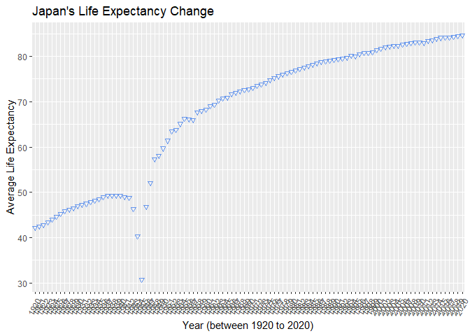

```r
long_life_expectancy%>%
  filter(country== "Japan", years>= "1920"& years<= "2020")%>%
  ggplot(aes(x= years, y= average_life_expectancy))+
  geom_line()+
  geom_point(shape= 6, color= "cornflowerblue")+
  theme(axis.text.x = element_text(angle = 60, hjust = 1))+
  labs(title = "Japan's Life Expectancy Change", x= "Year (between 1920 to 2020)", y= "Average Life Expectancy")
```

```
## geom_path: Each group consists of only one observation. Do you need to adjust
## the group aesthetic?
```

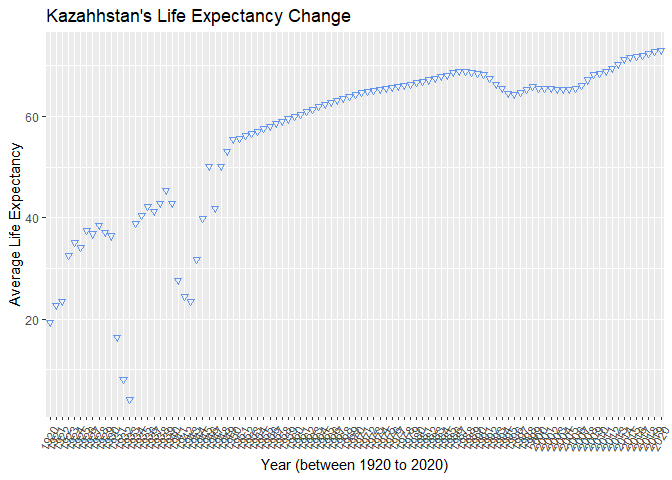

```r
long_life_expectancy%>%
  filter(country== "Kazakhstan", years>= "1920"& years<= "2020")%>%
  ggplot(aes(x= years, y= average_life_expectancy))+
  geom_line()+
  geom_point(shape= 6, color= "cornflowerblue")+
  theme(axis.text.x = element_text(angle = 60, hjust = 1))+
  labs(title = "Kazahhstan's Life Expectancy Change", x= "Year (between 1920 to 2020)", y= "Average Life Expectancy")
```

```r
names(long_pop_total)
```

```
## [1] "country"           "years"             "total_ population"
```

## Population Growth

6. (3 points) Which 5 countries have had the highest population growth over the past 100 years (1920-2020)?

```r
long_pop_total%>%
  filter(years >="1920" & years <="2020")%>%
  group_by(country)%>%
  summarise(min= min(`total_ population`), mean= mean(`total_ population`), max= max(`total_ population`))%>%
  arrange(desc(min))
```

```
## # A tibble: 195 x 4
##    country              min       mean        max
##    <chr>              <dbl>      <dbl>      <dbl>
##  1 China          472000000 885366337. 1440000000
##  2 India          317000000 684613861. 1380000000
##  3 United States  111000000 211485149.  331000000
##  4 Russia          77900000 121885149.  148000000
##  5 Germany         62400000  75167327.   83800000
##  6 Japan           55300000 100702970.  129000000
##  7 Indonesia       47300000 133104950.  274000000
##  8 United Kingdom  46500000  54655446.   67900000
##  9 France          38500000  50408911.   65300000
## 10 Italy           37100000  51302970.   60700000
## # ... with 185 more rows
```

7. (4 points) Produce a plot that shows the 5 countries that have had the highest population growth over the past 100 years (1920-2020). Which countries appear to have had exponential growth?

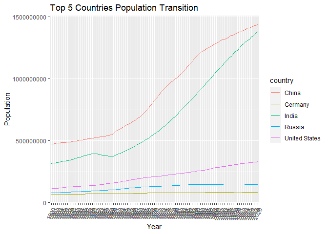

```r
long_pop_total %>%
  filter(country=="China" | country=="India" | country=="United States" | country=="Russia" | country=="Germany", years >="1920" & years <="2020") %>%
  select(country, years, `total_ population`) %>%
  ggplot(aes(x=years, y= `total_ population`,group= country, color=country))+
  geom_line()+
  theme(axis.text.x = element_text(angle = 60, hjust = 1))+
  labs(title = "Top 5 Countries Population Transition", y= "Population", x= "Year")
```

## Income

The units used for income are gross domestic product per person adjusted for differences in purchasing power in international dollars.

```r
names(long_income_ppp_gpd)
```

```
## [1] "country"           "years"             "average_income_pp"
```

8. (4 points) As in the previous questions, which countries have experienced the biggest growth in per person GDP. Show this as a table and then plot the changes for the top 5 countries. With a bit of research, you should be able to explain the dramatic downturns of the wealthiest economies that occurred during the 1980’s.

```r
long_income_ppp_gpd%>%
  filter(years >="1920" & years <="2020")%>%
  group_by(country)%>%
  summarise(min= min(average_income_pp), mean= mean(average_income_pp), max= max(average_income_pp))%>%
  arrange(desc(min, max))
```

```
## # A tibble: 193 x 4
##    country          min   mean   max
##    <chr>          <dbl>  <dbl> <dbl>
##  1 Switzerland    12900 35676. 59100
##  2 Norway          7980 32904. 67500
##  3 Australia       7910 22795. 45800
##  4 United States   7270 27304. 57500
##  5 New Zealand     7130 19635. 36700
##  6 Denmark         6880 24547. 48900
##  7 United Kingdom  6660 20199. 40700
##  8 Monaco          6630 29004. 62000
##  9 Belgium         6410 21085. 43900
## 10 Argentina       6100 11752. 19800
## # ... with 183 more rows
```

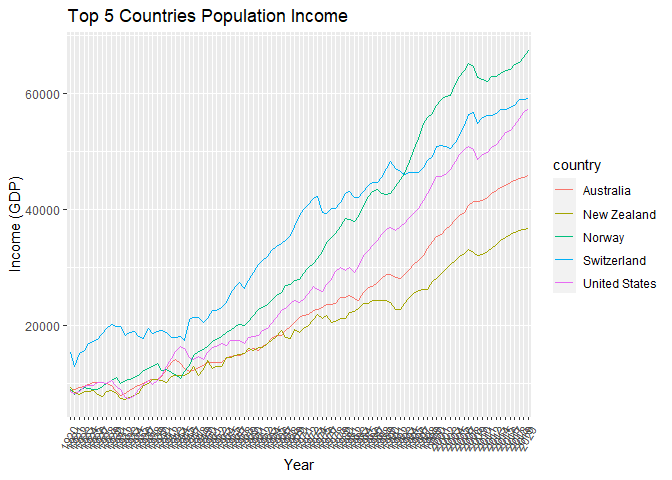

```r
long_income_ppp_gpd %>%
  filter(country=="Switzerland" | country=="Norway" | country=="United States" | country=="Australia" | country=="New Zealand", years >="1920" & years <="2020") %>%
  select(country, years, average_income_pp) %>%
  ggplot(aes(x=years, y= average_income_pp,group= country, color=country))+
  geom_line()+
  theme(axis.text.x = element_text(angle = 60, hjust = 1))+
  labs(title = "Top 5 Countries Population Income", y= "Income (GDP)", x= "Year")
```

Looking at the change in GDP, this can be the GDP at start year and end year = subtraction, this does not account for good and bad years.MAybe look at min and max of both years.

9. (3 points) Create three new objects that restrict each data set (life expectancy, population, income) to the years 1920-2020. Hint: I suggest doing this with the long form of your data. Once this is done, merge all three data sets using the code I provide below. You may need to adjust the code depending on how you have named your objects. I called mine `life_expectancy_100`, `population_100`, and `income_100`. For some of you, learning these `joins` will be important for your project.

```r
life_1920_2020 <-
  long_life_expectancy%>%
  filter(years >="1920" & years <="2020")

pop_1920_2020 <-
  long_pop_total%>%
  filter(years >="1920" & years <="2020")
income_1920_2020 <-
  long_income_ppp_gpd%>%
  filter(years >="1920" & years <="2020")
```

```r
gapminder_join <- inner_join(life_1920_2020, pop_1920_2020, by= c("country", "years"))
gapminder_join <- inner_join(gapminder_join, income_1920_2020, by= c("country", "years"))
gapminder_join
```

```
## # A tibble: 18,887 x 5
##    country     years average_life_expectancy `total_ populatio~ average_income_~
##    <chr>       <chr>                   <dbl>              <dbl>            <dbl>
##  1 Afghanistan 1920                     30.6           10600000             1490
##  2 Afghanistan 1921                     30.7           10500000             1520
##  3 Afghanistan 1922                     30.8           10300000             1550
##  4 Afghanistan 1923                     30.8            9710000             1570
##  5 Afghanistan 1924                     30.9            9200000             1600
##  6 Afghanistan 1925                     31              8720000             1630
##  7 Afghanistan 1926                     31              8260000             1650
##  8 Afghanistan 1927                     31.1            7830000             1680
##  9 Afghanistan 1928                     31.1            7420000             1710
## 10 Afghanistan 1929                     31.2            7100000             1740
## # ... with 18,877 more rows
```

10. (4 points) Use the joined data to perform an analysis of your choice. The analysis should include a comparison between two or more of the variables `life_expectancy`, `population`, or `income.`

[figure not shown]

```r
gapminder_join%>%
  filter(country=="United States")%>%
  ggplot(aes(x= average_life_expectancy, y= average_life_expectancy )) +
  geom_point(shape=4, color= "cornflowerblue")+
  geom_smooth(method="lm")+
  labs(title = "How Income affects Life Expectancy ", x= "Average Age (Years)", y= "Income (GDP)")
```